# GSE148731: Generate toptable for MF2 data

## Differential expression analysis

### Creating a design matrix

```r
design <- stats::model.matrix(~0+group)
colnames(design) <- gsub("group", "", colnames(design))
design
```

```
  Ctrl Infected
1    1        0
2    1        0
3    1        0
4    0        1
5    0        1
6    0        1
attr(,"assign")
[1] 1 1
attr(,"contrasts")
attr(,"contrasts")$group
[1] "contr.treatment"
```

### Set up contrasts

```r
contr.matrix <- limma::makeContrasts(
  Infected.vs.Ctrl = Infected - Ctrl,
   levels = colnames(design)
   )
contr.matrix
```

```
          Contrasts
Levels     Infected.vs.Ctrl
  Ctrl                   -1
  Infected                1
```

### Removing heteroscedascity from count data

> *“It has been shown that for RNA-seq count data, the variance is not independent of the mean (Law et al. 2014) – this is true of raw counts or when transformed to log-CPM values. Methods that model counts using a Negative Binomial distribution assume a quadratic mean-variance relationship. In limma, linear modelling is carried out on the log-CPM values which are assumed to be normally distributed and the mean-variance relationship is accommodated using precision weights calculated by the voom function.”*

> *“When operating on a DGEList-object, voom converts raw counts to log-CPM values by automatically extracting library sizes and normalisation factors from x itself. Additional normalisation to log-CPM values can be specified within voom using the normalize.method argument.”*

> *“The mean-variance relationship of log-CPM values for this dataset is shown in the left-hand panel of the next figure. Typically, the voom-plot shows a decreasing trend between the means and variances resulting from a combination of technical variation in the sequencing experiment and biological variation amongst the replicate samples from different cell populations. Experiments with high biological variation usually result in flatter trends, where variance values plateau at high expression values.”*

> *“Experiments with low biological variation tend to result in sharp decreasing trends. Moreover, the voom-plot provides a visual check on the level of filtering performed upstream. If filtering of lowly-expressed genes is insufficient, a drop in variance levels can be observed at the low end of the expression scale due to very small counts. If this is observed, one should return to the earlier filtering step and increase the expression threshold applied to the dataset.”*

```r
# elist <- limma::voom(dgel, design, plot=TRUE)
elist <- limma::voom(dgel.3, design, save.plot=TRUE)
# class(elist) # "EList" ("limma")
elist
```

```
An object of class "EList"
$genes
```

|  | genes |
| --- | --- |
| A1BG | A1BG |
| A1BG-AS1 | A1BG-AS1 |
| A2M | A2M |
| A2M-AS1 | A2M-AS1 |
| A2ML1-AS1 | A2ML1-AS1 |

```
17080 more rows ...

$targets
```

|  | group | lib.size | norm.factors |
| --- | --- | --- | --- |
| Ctrl.1 | Ctrl | 15892487 | 1.0714512 |
| Ctrl.2 | Ctrl | 22224541 | 1.0732739 |
| Ctrl.3 | Ctrl | 34478516 | 1.0633160 |
| Infected.1 | Infected | 12286995 | 0.9441129 |
| Infected.2 | Infected | 6913906 | 0.9435589 |
| Infected.3 | Infected | 12817184 | 0.9180402 |

```
$E
             Ctrl.1    Ctrl.2    Ctrl.3 Infected.1 Infected.2 Infected.3
A1BG       4.172118  4.070883  4.068547   3.794568   3.757393   3.847469
A1BG-AS1   4.146718  4.182343  4.100609   4.070938   3.875835   4.277095
A2M       10.144033 10.166813 10.097652   9.095293   8.883145   8.788744
A2M-AS1    4.177145  4.074740  3.907789   2.122407   2.839855   2.614613
A2ML1-AS1  2.757920  2.629206  2.347701   2.346724   1.991859   2.214810
17080 more rows ...

$weights
          [,1]      [,2]      [,3]      [,4]      [,5]      [,6]
[1,]  77.10578  97.02597 123.93683  53.54145  33.85062  55.43165
[2,]  78.64293  98.73822 125.56491  62.47871  39.29005  64.62670
[3,] 196.86952 199.00827 201.50080 188.74362 183.02490 189.10040
[4,]  75.18417  94.84765 121.83491  26.87021  18.53379  27.68929
[5,]  33.47415  43.57671  62.21061  22.92089  16.08963  23.55976
17080 more rows ...

$design
  Ctrl Infected
1    1        0
2    1        0
3    1        0
4    0        1
5    0        1
6    0        1
attr(,"assign")
[1] 1 1
attr(,"contrasts")
attr(,"contrasts")$group
[1] "contr.treatment"


$voom.xy
$x
     A1BG  A1BG-AS1       A2M   A2M-AS1 A2ML1-AS1
 7.895255  8.052348 13.472705  7.232850  6.324795
17080 more elements ...

$y
     A1BG  A1BG-AS1       A2M   A2M-AS1 A2ML1-AS1
0.2294749 0.3805435 0.3373091 0.5260073 0.4417886
17080 more elements ...

$xlab
[1] "log2( count size + 0.5 )"

$ylab
[1] "Sqrt( standard deviation )"


$voom.line
$x
[1] 4.187468 4.218092 4.218445 4.225597 4.235089
17080 more elements ...

$y
[1] 0.5386878 0.5371746 0.5371572 0.5368038 0.5363348
17080 more elements ...
```

### Fitting linear model

> *“Linear modelling in limma is carried out using the lmFit and contrasts.fit functions originally written for application to microarrays. The functions can be used for both microarray and RNA-seq data and fit a separate model to the expression values for each gene. Next, empirical Bayes moderation is carried out by borrowing information across all the genes to obtain more precise estimates of gene-wise variability (Smyth 2004). The model’s residual variances are plotted against average expression values in the next figure [on the right]. It can be seen from this plot that the variance is no longer dependent on the mean expression level.”*

```r
vfit <- limma::lmFit(elist, design)
vfit <- limma::contrasts.fit(vfit, contrasts=contr.matrix)
efit <- limma::eBayes(vfit)
```

```r
par(mfrow=c(1,2))
plot(x=elist$voom.xy$x, y=elist$voom.xy$y, pch = 16, cex = 0.3,
     xlab=elist$voom.xy$xlab,
     ylab=elist$voom.xy$ylab,
     main="voom: Mean-variance trend")
lines(x=elist$voom.line$x, y=elist$voom.line$y, type="l", col="red")
```

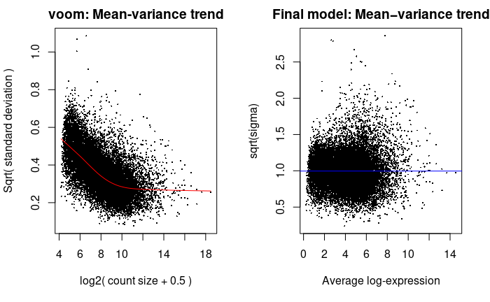

```r
limma::plotSA(efit, main="Final model: Mean−variance trend")
```

## Eploring differential gene epression

### Examining the number of differentially expressed genes

> *“For a quick look at differential expression levels, the number of significantly up- and down-regulated genes can be summarised in a table. Significance is defined using an adjusted p-value cutoff that is set at 5% by default.”*

```r
maximum.p.value <- 0.01
cat("Maximum p.value:<b>", maximum.p.value, "</b><br>\n")
```

Maximum p.value: **0.01**

```r
minimum.fold.change <- 1
cat("Minimum log2 fold change:<b>", minimum.fold.change, "</b><br>\n")
```

Minimum log2 fold change: **1**

```r
# p.value: numeric value between 0 and 1 giving the required family-wise error rate or false discovery rate.
# lfc: numeric, minimum absolute log2-fold-change required.

summary(limma::decideTests(efit, p.value=maximum.p.value, lfc=minimum.fold.change))
```

```
       Infected.vs.Ctrl
Down               1109
NotSig            14641
Up                 1335
```

## Toptable

### Generate toptable with limma

```r
top.table <- limma::topTable(efit, number=Inf, sort.by="logFC") %>%
  dplyr::rename(Gene.symbol = genes)
```

Print first 6 rows (suppressed):

```r
arrange(top.table, logFC) %>%
  head %>%
  knitr::kable(., row.names=F) %>% kableExtra::kable_styling(bootstrap_options = c("striped", "hover"))
```

| Gene.symbol | logFC | AveExpr | t | P.Value | adj.P.Val | B |
| --- | --- | --- | --- | --- | --- | --- |
| CCDC152 | -7.524136 | 5.131761 | -34.80029 | 0 | 0 | 20.28837 |
| SEPP1 | -7.330350 | 5.726882 | -41.98771 | 0 | 0 | 22.33582 |
| SLC40A1 | -5.469306 | 3.123064 | -25.41330 | 0 | 0 | 17.01217 |
| MS4A6A | -5.214462 | 5.657760 | -23.41861 | 0 | 0 | 16.38226 |
| FCN1 | -5.133757 | 4.752492 | -34.48711 | 0 | 0 | 20.48425 |
| SORL1 | -5.111675 | 5.767182 | -41.16829 | 0 | 0 | 22.61844 |

Print first 6 rows (induced):

```r
arrange(top.table, desc(logFC)) %>%
  head %>%
  knitr::kable(., row.names=F) %>% kableExtra::kable_styling(bootstrap_options = c("striped", "hover"))
```

| Gene.symbol | logFC | AveExpr | t | P.Value | adj.P.Val | B |
| --- | --- | --- | --- | --- | --- | --- |
| CXCL8 | 9.795100 | 8.711935 | 45.42686 | 0 | 0 | 24.02118 |
| IL1B | 9.369129 | 8.142136 | 40.72751 | 0 | 0 | 22.76563 |
| INHBA | 9.227757 | 5.121469 | 32.90468 | 0 | 0 | 19.86808 |
| AC005027.3 | 9.200438 | 5.137977 | 32.83545 | 0 | 0 | 19.85799 |
| CXCL1 | 8.877153 | 4.845333 | 24.09512 | 0 | 0 | 16.61144 |
| IL7R | 7.901586 | 7.051781 | 41.46011 | 0 | 0 | 22.92265 |

### Save toptable

```r
out.file <- paste(this.script, gsub("-", "_", Sys.Date()), "txt", sep=".")
write.table(top.table, file=out.file, sep="\t", row.names = F, col.names = T)
cat(out.file)
```

```
GSE148731_toptable_MF2_01.Rmd.2020_07_09.txt
```

## Plot MF1 versus MF2

```r
list.files()
```

```
 [1] "GSE148731_3_MF1_infected_versus_non_infected_24_hours.xlsx" "GSE148731_4_MF2_infected_versus_non-infected_24_hours.xlsx"
 [3] "GSE148731_toptable_MF1_01.nb.html"                          "GSE148731_toptable_MF1_01.Rmd"
 [5] "GSE148731_toptable_MF1_01.Rmd.2020_07_09.txt"               "GSE148731_toptable_MF2_01.nb.html"
 [7] "GSE148731_toptable_MF2_01.Rmd"                              "GSE148731_toptable_MF2_01.Rmd.2020_07_09.txt"
 [9] "GSE8731_processed_01.nb.html"                               "GSE8731_processed_01.Rmd"
```

```r
mf1 <- select(tt.mf1, Gene.symbol, logFC) %>%
  dplyr::rename(MF1 = logFC)
mf2 <- select(top.table, Gene.symbol, logFC, MF2 = logFC)
mf12 <- merge(x=mf1, y=mf2, by="Gene.symbol", all=FALSE) #%>%
  # tidyr::pivot_longer(-Gene.symbol) %>%
  # set_colnames(c("Gene", "Dataset", "logFC"))
head(mf12)
```

|  | Gene.symbol | MF1 | MF2 |
| --- | --- | --- | --- |
| 1 | A1BG | -0.32567519 | -0.28981092 |
| 2 | A1BG-AS1 | -0.09309872 | -0.03427896 |
| 3 | A2M | -0.08812665 | -1.21326801 |
| 4 | A2M-AS1 | -0.34926922 | -1.54064472 |
| 5 | A2ML1-AS1 | 0.23477647 | -0.32858934 |
| 6 | A2MP1 | 0.21266430 | -0.87704551 |

```r
with(mf12, cor(MF1, MF2))
```

```
[1] 0.4952674
```

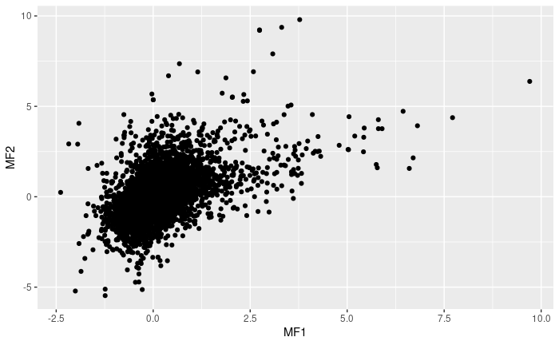

```r
gg1 <- ggplot(mf12, aes(x=MF1, y=MF2)) + geom_point()
gg1
```

## Session info

```r
Sys.time()
```

```r
# sessionInfo()
devtools::session_info()
```

|  | setting | value |
| --- | --- | --- |
| version | version | R version 3.5.3 (2019-03-11) |
| os | os | CentOS Linux 7 (Core) |
| system | system | x86_64, linux-gnu |
| ui | ui | RStudio |
| language | language | (EN) |
| collate | collate | en_GB.UTF-8 |
| ctype | ctype | en_GB.UTF-8 |
| tz | tz | Europe/London |
| date | date | 2020-07-09 |